# Tema 6: Grafos y árboles soporte

Optimización y Análisis de Redes

DSLAB

2026-08-07

## Objetivos de aprendizaje

1. **Definir** grafos dirigidos y no dirigidos, vecindades, grados e incidencias de corte.
2. **Diferenciar** cadenas, caminos, ciclos y circuitos, y clasificar la conexidad en digrafos.
3. **Caracterizar** grafos planares y bipartitos mediante Euler, Dudeney y Kuratowski.
4. **Formular** matrices de adyacencia e incidencia (TUM), vectores ($\alpha, \beta$) y listas de adyacencia.
5. **Caracterizar** las propiedades equivalentes de árboles y el vector de padres.
6. **Aplicar** Kruskal y Prim para el MST y construir modelos de *Single-Linkage Clustering*.

# El problema de los puentes de Königsberg (Euler, 1736)

## Contexto histórico y los 7 puentes

- **Nacimiento de la Teoría de Grafos**: Formulado por Leonhard Euler en 1736.
- **Geografía urbana de Königsberg**: Cuatro regiones ($A, B, C, D$) separadas por el río Pregel y conectadas por 7 puentes de madera.
- **El Desafío**: Determinar si existe un paseo que cruce **cada uno de los 7 puentes exactamente una sola vez** y regrese al punto inicial.

[figure not shown]

## Abstracción topológica de Euler

[figure not shown]

[figure not shown]

## Imposibilidad del recorrido en Königsberg

**Principio de Euler**

Un grafo conexo admite un circuito euleriano s.i.s. **todos sus vértices tienen grado par**.

# Conceptos fundamentales

## Definición formal de grafos no dirigidos y digrafos

**Definición: Grafo no dirigido**

Un **grafo no dirigido** $G = (V, E)$ consiste en un conjunto finito no vacío de **vértices** $V$ y un conjunto $E$ de **aristas** formadas por pares no ordenados $\{u, v\}$ con $u, v \in V$.

**Definición: Grafo dirigido (Digrafo)**

Un **digrafo** $G = (V, U)$ consiste en un conjunto de vértices $V$ y un conjunto $U$ de **arcos** formados por tuplas ordenadas $(u, v)$ donde $u$ es el nodo origen y $v$ el nodo destino.

## Ejemplo: Red de transporte aéreo

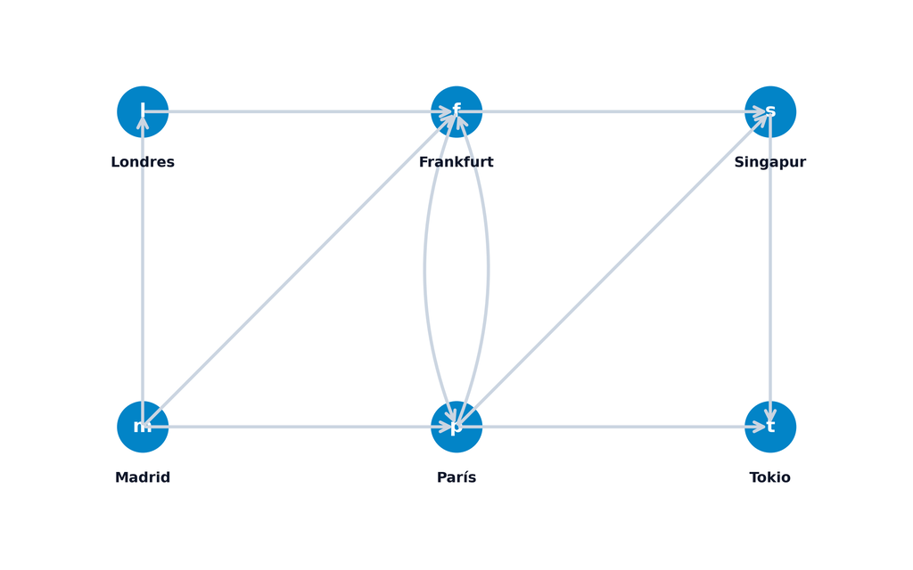

## Estructura abstracta de digrafos

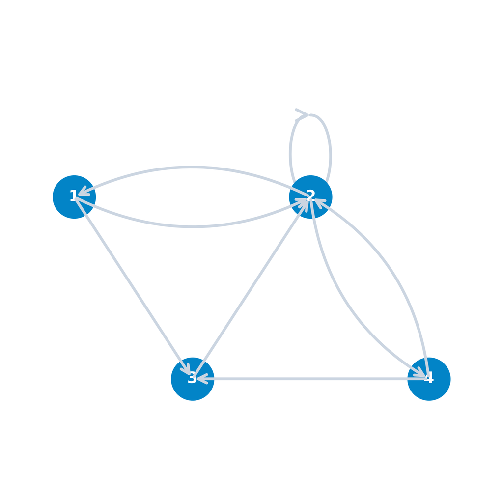

## Adyacencia y vecindades de un nodo

**Definición: Adyacencia y vecindades**

Dado un digrafo $G = (V, U)$ o grafo no dirigido $G = (V, E)$ y un nodo $i \in V$:

- **Nodos adyacentes**: Dos nodos $i, j \in V$ son adyacentes si existe una conexión directa entre ellos ($(i,j) \in U$ ó $(j,i) \in U$).
- **Conjunto de Sucesores**: $\Gamma^+(i) = \{j \in V : (i, j) \in U\}$, nodos hacia los que parten arcos desde $i$.
- **Conjunto de Predecesores**: $\Gamma^-(i) = \{j \in V : (j, i) \in U\}$, nodos desde los que llegan arcos a $i$.
- **Vecindad Total**: $\Gamma(i) = \Gamma^+(i) \cup \Gamma^-(i)$, conjunto combinado de sucesores y predecesores de $i$.

## Incidencia de arcos

**Definición: Incidencia de arcos**

Dado un digrafo $G = (V, U)$ o grafo no dirigido $G = (V, E)$:

- **Arcos adyacentes**: Dos arcos $u_1, u_2 \in U$ son adyacentes cuando comparten al menos un nodo extremo común (por ejemplo, los arcos $(1, 2)$ y $(2, 4)$ en el nodo $2$).
- **Incidencia de salida**: Un arco $u = (i, j) \in U$ es **incidente de salida** en su nodo origen $i$.
- **Incidencia de entrada**: Un arco $u = (i, j) \in U$ es **incidente de entrada** en su nodo destino $j$.

## Semigrados exterior e interior

**Definición: Semigrados exterior e interior**

Dado un digrafo $G = (V, U)$ y un nodo $i \in V$:

- **Semigrado exterior**:
  $$d^+(i) = |\Gamma^+(i)|$$
  Número exacto de arcos salientes que parten del nodo $i$.
- **Semigrado interior**:
  $$d^-(i) = |\Gamma^-(i)|$$
  Número exacto de arcos entrantes que ingresan en el nodo $i$.

## Grado total y nodos notables

**Definición: Grado total y nodos notables**

Dado un grafo $G = (V, E)$ o digrafo $G = (V, U)$ y un nodo $i \in V$:

- **Grado total**:
  $$d(i) = d^+(i) + d^-(i)$$
  Número total de arcos o aristas incidentes en el nodo $i$.
- **Nodo pendiente o hoja**: Nodo con grado total exactamente igual a 1 ($d(i) = 1$).
- **Nodo aislado**: Nodo desprovisto de conexiones incidentes ($d(i) = 0$).

## Ilustración de vecindades y semigrados

- **Vecindad del nodo 3**:
  - Sucesores: $\Gamma^+(3) = \{2\}$
  - Predecesores: $\Gamma^-(3) = \{1, 4\}$
  - Vecindad total: $\Gamma(3) = \{1, 2, 4\}$
- **Semigrados y Nodos notables**:
  - Entrada y salida: $d^+(3)=1, d^-(3)=2$
  - Grado total: $d(3) = 1 + 2 = 3$
  - Nodo 5: $d^+(5)=0, d^-(5)=1 \implies d(5)=1$

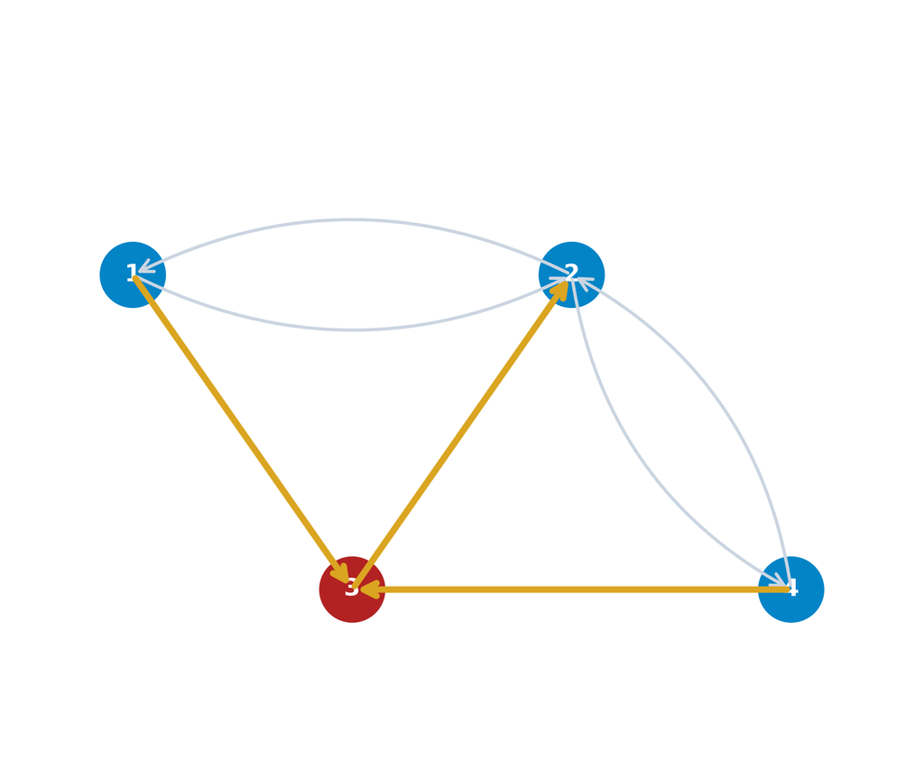

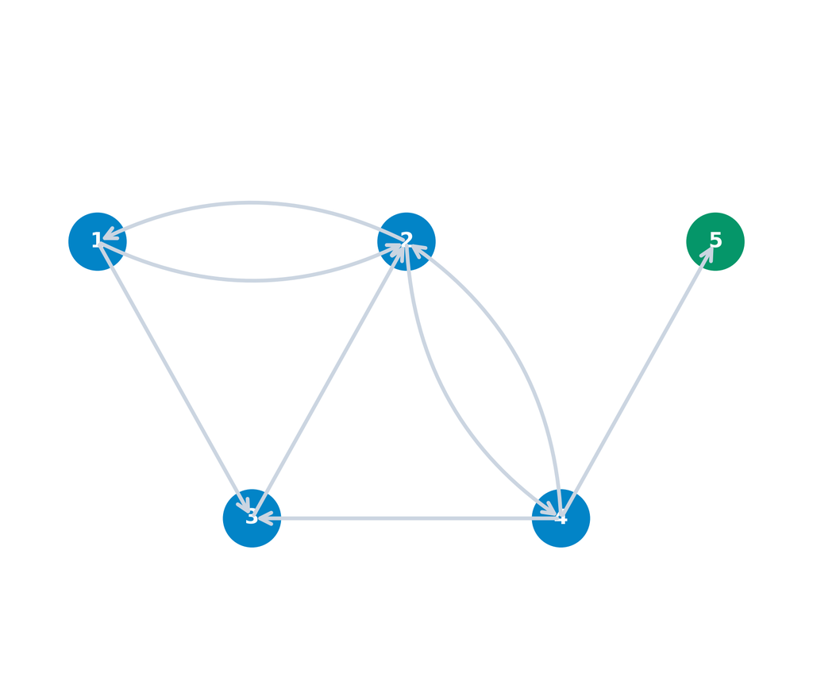

## Lema del apretón de manos (Handshaking Lemma)

**Teorema de la suma de grados (Handshaking Lemma)**

En todo grafo no dirigido $G = (V, E)$ con $|V| = n$ vértices y $|E| = m$ aristas, la suma de los grados de todos los vértices es igual al doble del número total de aristas:
$$\sum_{v \in V} d(v) = 2m$$

- **Significado combinatorio**:
  - Cada arista no dirigida conecta exactamente dos vértices extremos.
  - Al sumar los grados de todos los nodos, cada arista se contabiliza exactamente dos veces (apretón de manos de dos extremos).

## Incidencia de conjuntos de nodos y cortes

**Definición: Incidencia y corte de un conjunto A**

Dado un digrafo $G = (V, U)$ y un subconjunto propio de nodos $A \subset V$:

- **Incidencia Exterior $w^+(A)$**: Conjunto de arcos que parten de $A$ y finalizan fuera de $A$:  
  $w^+(A) = \{(i, j) \in U : i \in A, \, j \in V \setminus A\}$
- **Incidencia Interior $w^-(A)$**: Conjunto de arcos que parten de fuera de $A$ e ingresan en $A$:  
  $w^-(A) = \{(i, j) \in U : i \in V \setminus A, \, j \in A\}$
- **Corte $w(A)$**: Unión de las incidencias exterior e interior de la frontera:  
  $w(A) = w^+(A) \cup w^-(A)$

## Ejemplo: Corte e incidencias para A = {2, 3}

Para el subconjunto de nodos $A = \{2, 3\}$:

- **Incidencia exterior** (salientes de $A$):
  $$\color{#b91c1c}{w^+(A) = \{(2,4), (3,1), (3,5)\}}$$
- **Incidencia interior** (entrantes a $A$):
  $$\color{#0284c7}{w^-(A) = \{(1,2), (4,3)\}}$$
- **Corte total** (frontera cruzada):
  $$\begin{aligned}
  w(A) &= \color{#b91c1c}{w^+(A)} \cup \color{#0284c7}{w^-(A)} \\
  &= \{\color{#0284c7}{(1,2)}, \color{#b91c1c}{(2,4)}, \color{#b91c1c}{(3,1)}, \color{#b91c1c}{(3,5)}, \color{#0284c7}{(4,3)}\}
  \end{aligned}$$

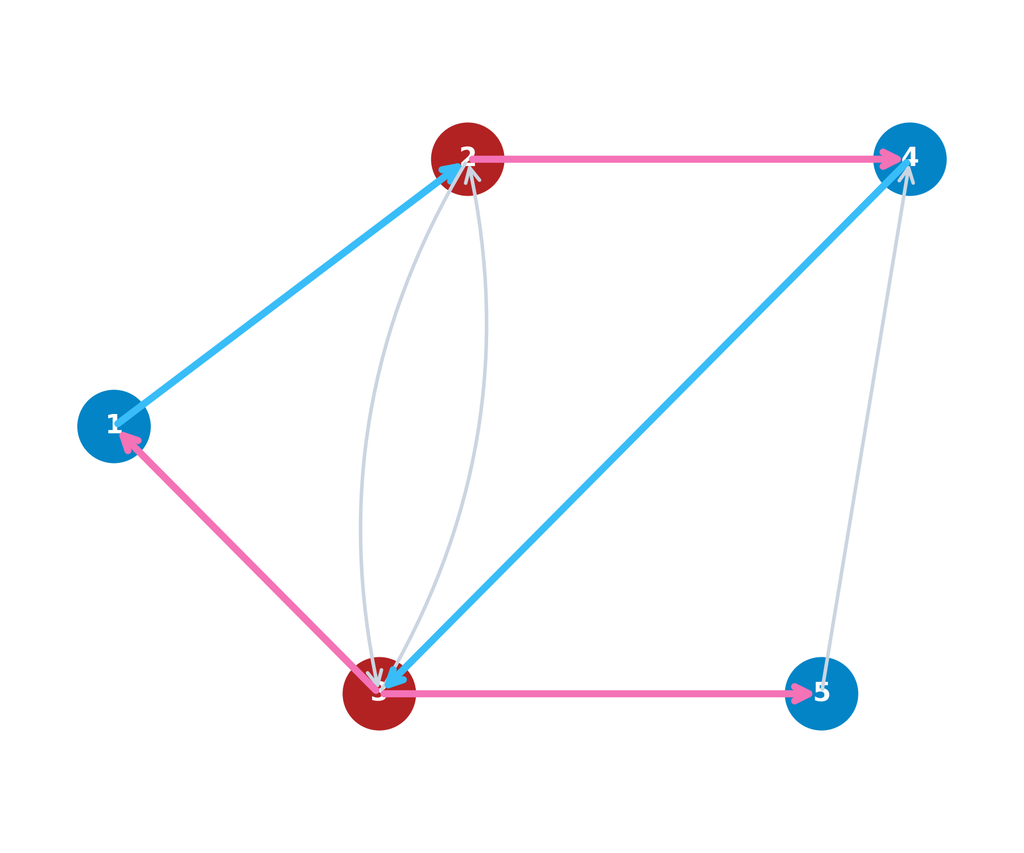

## Multigrafos y p-grafos

**Definición: Multigrafo y p-grafo**

- **Multigrafo / Multidigrafo**: Admite múltiples conexiones o aristas en paralelo entre un mismo par de vértices.
- **Multiplicidad**: Número exacto de conexiones paralelas entre dos nodos.
- **$p$-Grafo**: Multigrafo en el que la máxima multiplicidad de cualquier par de nodos es $p$.

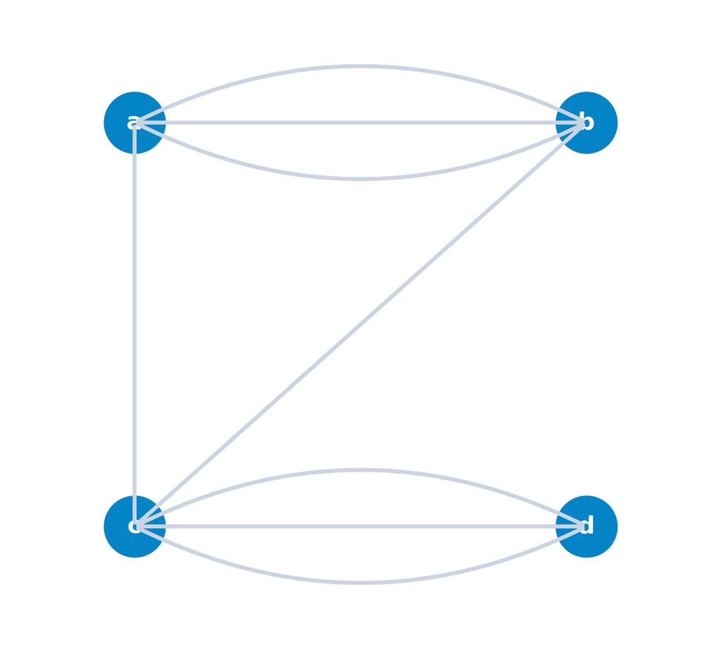

## Grafos simples

**Definición: Grafo simple**

Un **grafo simple** (o **digrafo simple**) es un grafo de multiplicidad 1 desprovisto de autodirecciones o bucles $(i, i)$.

- **Propiedad de exclusión**:
  - Para cualquier par de vértices $i, j \in V$, existe como máximo una única arista $\{i, j\} \in E$ (o un único arco $(i, j) \in U$).
  - Ningún nodo está conectado consigo mismo mediante un bucle $(i, i) \notin U$.

## Grafos completos (no dirigidos) y Clanes ($K_n$)

**Definición: Grafo completo y Clan Kn**

Un **grafo completo** $G = (V, E)$ (o **clan / clique** $K_n$) es un grafo simple no dirigido en el que todo par de vértices distintos se encuentra directamente conectado por una arista:
$$\{i, j\} \in E, \quad \forall i \neq j \in V$$

- **Número total de aristas**: $m = \binom{n}{2} = \frac{n(n-1)}{2}$.

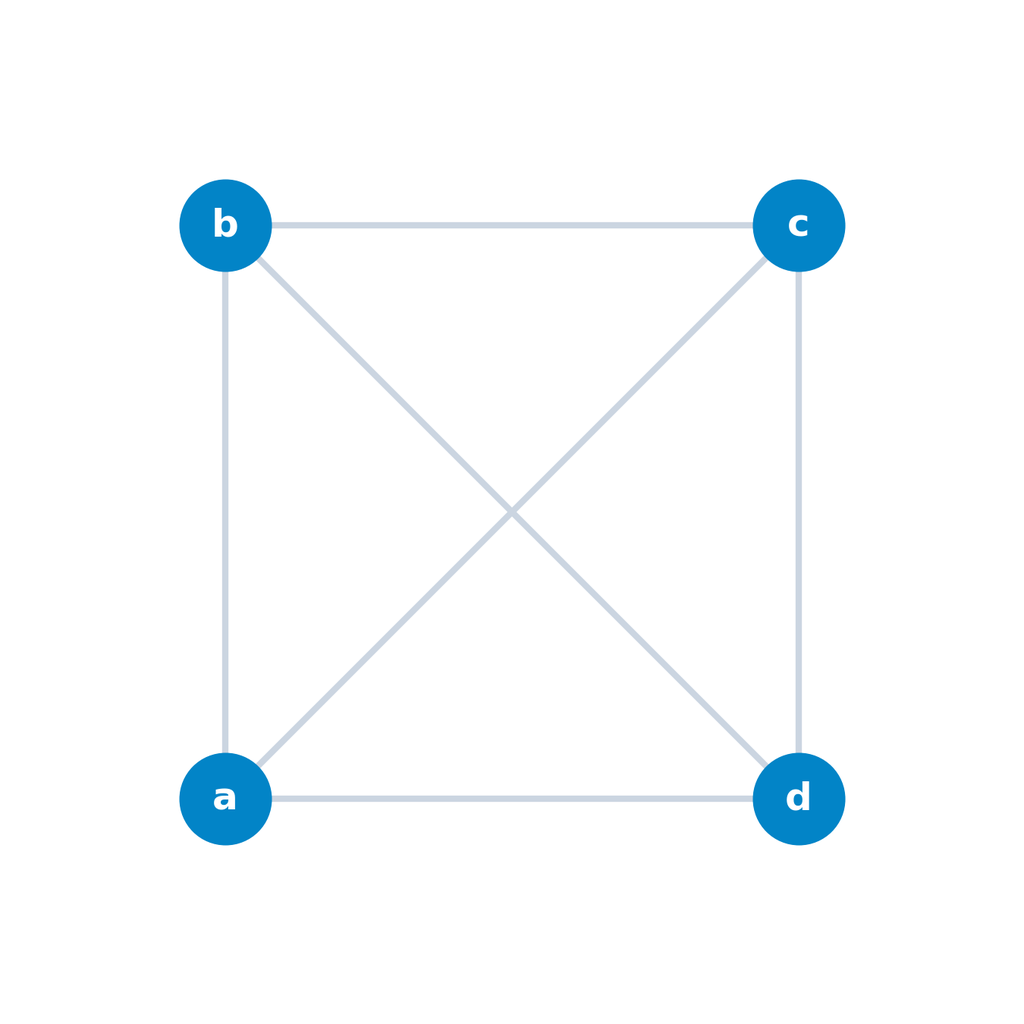

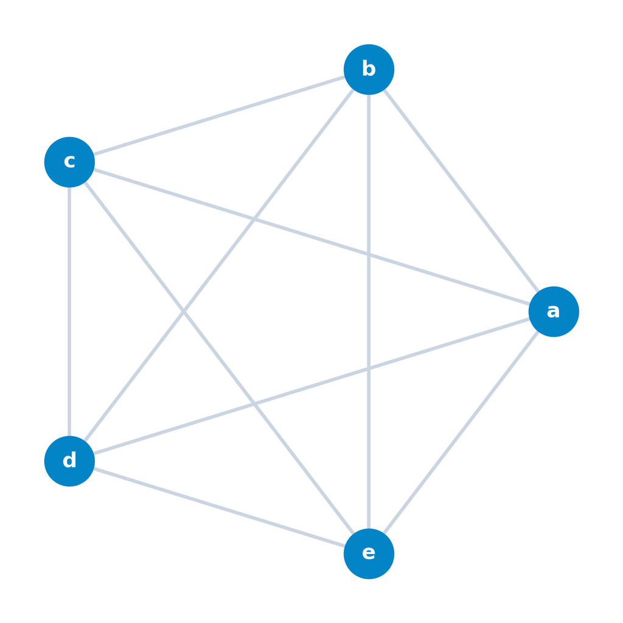

## Digrafos completos

**Definición: Digrafo completo**

Un digrafo $G = (V, U)$ se dice **completo** si para todo par de vértices distintos $i \neq j$, la ausencia de un arco en una dirección implica la existencia obligatoria del arco en sentido inverso:
$$(i, j) \notin U \implies (j, i) \in U \quad (\forall i \neq j)$$

- **Interpretación orientada**: Se garantiza al menos un sentido de comunicación directa entre cualquier pareja de vértices.

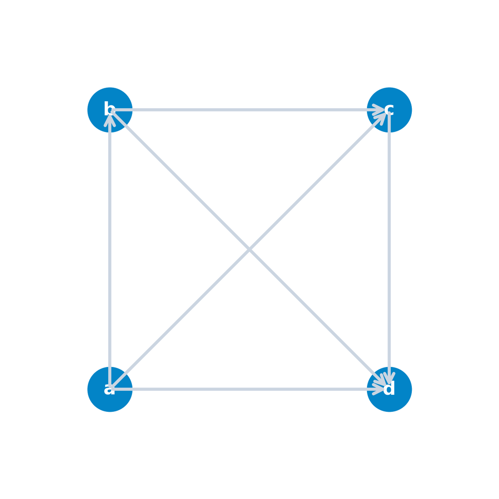

## Grafo base original de referencia $G = (V, U)$

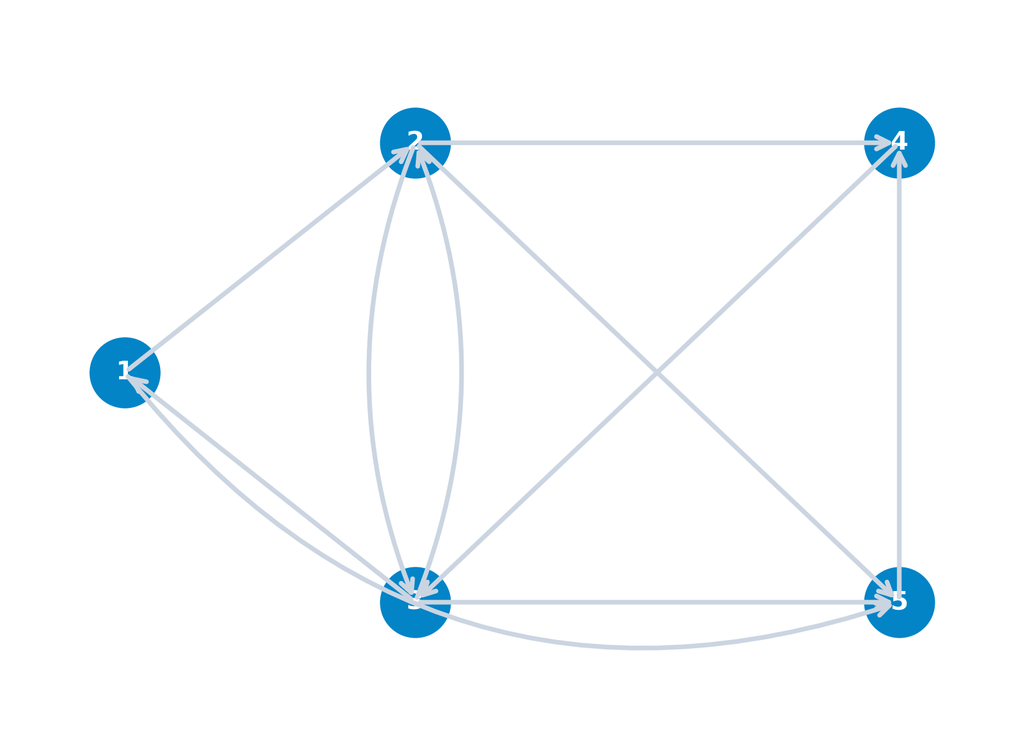

## Subgrafos inducidos (por nodos)

**Definición: Subgrafo inducido**

Dado $G = (V, U)$ y un subconjunto de vértices $A \subset V$, el **subgrafo inducido** $G_A = (A, U_A)$ conserva únicamente los nodos de $A$ y los arcos con ambos extremos en $A$:
$$U_A = \{(i, j) \in U : i, j \in A\}$$

- **Ejemplo para $A=\{1,2,5\}$**: Los nodos $\{3, 4\}$ y sus arcos incidentes desaparecen por completo respecto a la red base $G$.

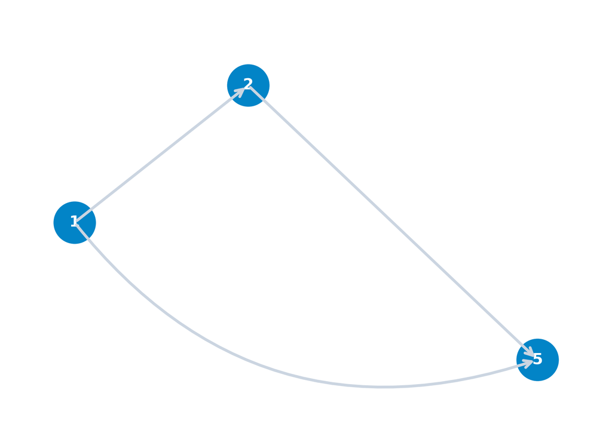

## Grafos parciales (por arcos)

**Definición: Grafo parcial**

Dado $G = (V, U)$ y un subconjunto de arcos $W \subset U$, el **grafo parcial** $G(W) = (V, W)$ conserva los $n$ vértices de $V$, restringiendo los arcos a $W$.

- **Ejemplo para $W=\{(1,2),(2,4),(5,4)\}$**: Los $n=5$ nodos de $G$ se preservan intactos. El nodo 3 permanece presente como **nodo aislado** ($d(3)=0$).

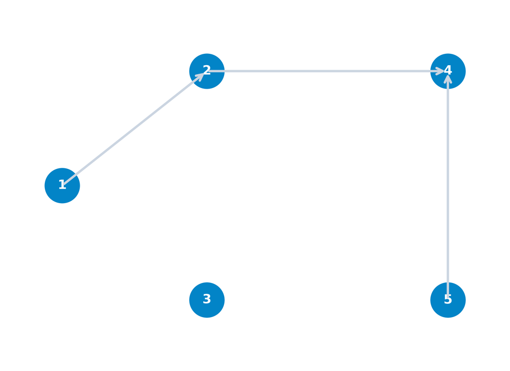

## Grafo complementario ($\bar{G}$)

**Definición: Grafo complementario**

Dado un grafo simple $G = (V, E)$, su **grafo complementario** $\bar{G} = (V, \bar{E})$ mantiene los mismos vértices y contiene exactamente las aristas no presentes en $E$:
$$\{i, j\} \in \bar{E} \iff \{i, j\} \notin E \quad (\forall i \neq j)$$

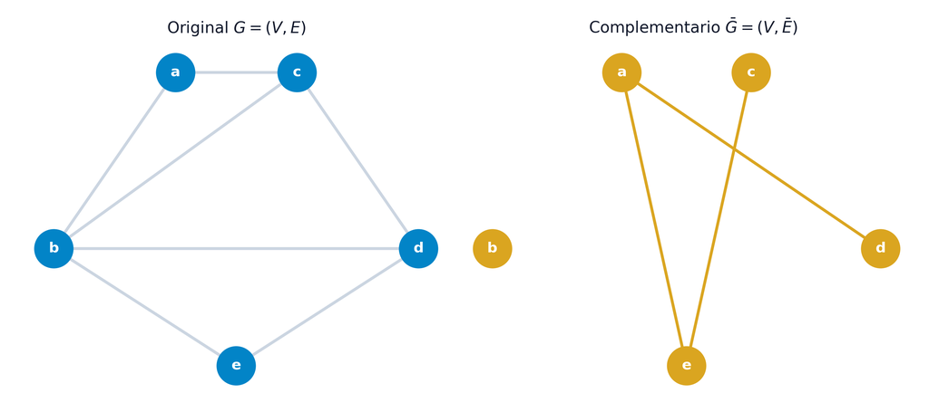

# Recorridos y conectividad en redes

## Recorridos en redes: Cadenas vs Caminos

**Diferencia conceptual fundamental**

- **Cadena $\mu$**: Secuencia de arcos adyacentes $\mu = (u_1, u_2, \dots, u_q)$ entre dos nodos que **no exige respetar la orientación de las flechas** (se pueden transitar en cualquier sentido). Caracteriza la **conectividad sintáctica/topológica**.
- **Camino $P$**: Secuencia de arcos orientados donde **todos los arcos se transitan strictly a favor de su sentido** ($u_k$ finaliza donde $u_{k+1}$ comienza). Caracteriza la **posibilidad real de transporte o flujo**.
- **En redes no dirigidas**, las nociones de cadena y camino resultan formalmente equivalentes.

## Propiedades de recorridos: Elementalidad y Simplicidad

**Definición: Elementalidad y Simplicidad**

Dado un digrafo $G = (V, U)$ o grafo $G = (V, E)$:

- **Elemental**: Una cadena o camino es **elemental** si **no repite ningún vértice** en su secuencia.
- **Simple**: Una cadena o camino es **simple** si **no repite ningún arco o arista** en su secuencia.
- **Red de aeropuertos de referencia**: $V = \{m, l, p, f, s, t\}$ (Madrid, Londres, París, Frankfurt, Singapur, Tokio).

## Ejemplo 1: Cadena elemental y simple ($\mu^1$)

- **Cadena $\mu^1[m, p]$ de longitud $q=3$**:
  $$\mu^1 = \{(m, l), (l, f), (p, f)\}$$
- Recorre $\{m, l, f, p\}$ sin repetir ninguno $\implies$ **Elemental**.
- Transita por 3 arcos distintos $\implies$ **Simple**.
- El arco $(p, f)$ en sentido inverso $\implies$ Es una **cadena** (no un camino).

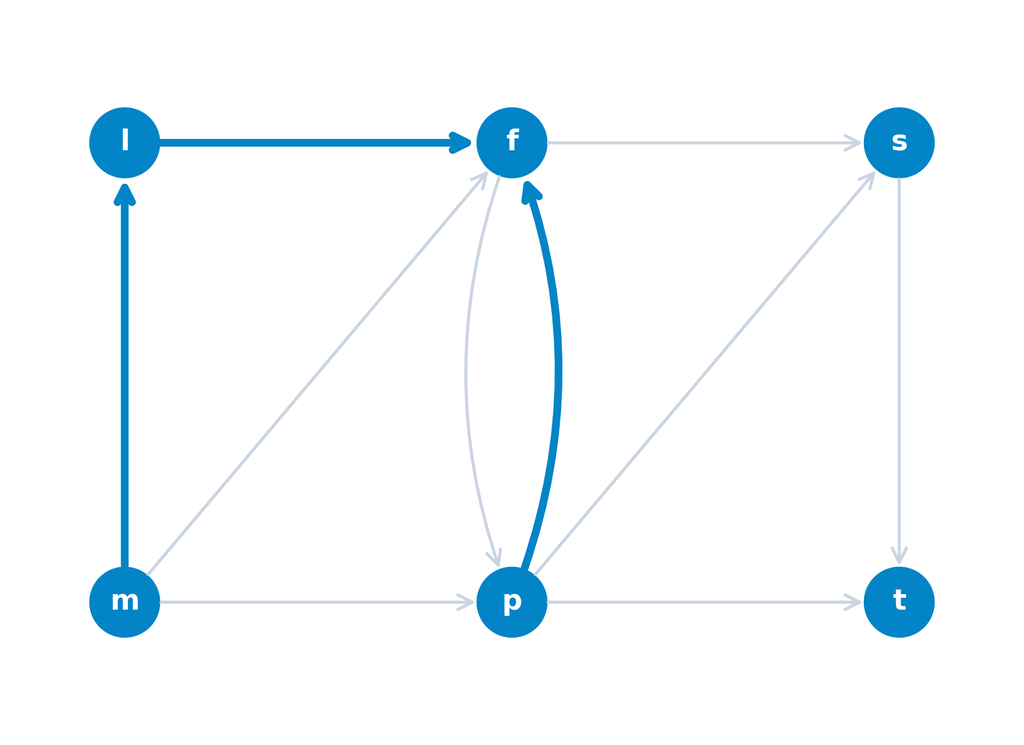

## Ejemplo 2: Camino elemental y simple ($\mu^2$)

- **Camino $\mu^2[p, t]$ de longitud $q=3$**:
  $$\mu^2 = \{(p, f), (f, s), (s, t)\}$$
- Todos los arcos en sentido directo ($p \to f \to s \to t$) $\implies$ Es un **camino**.
- No repite ningún vértice $\implies$ **Elemental**.
- No repite ningún arco $\implies$ **Simple**.

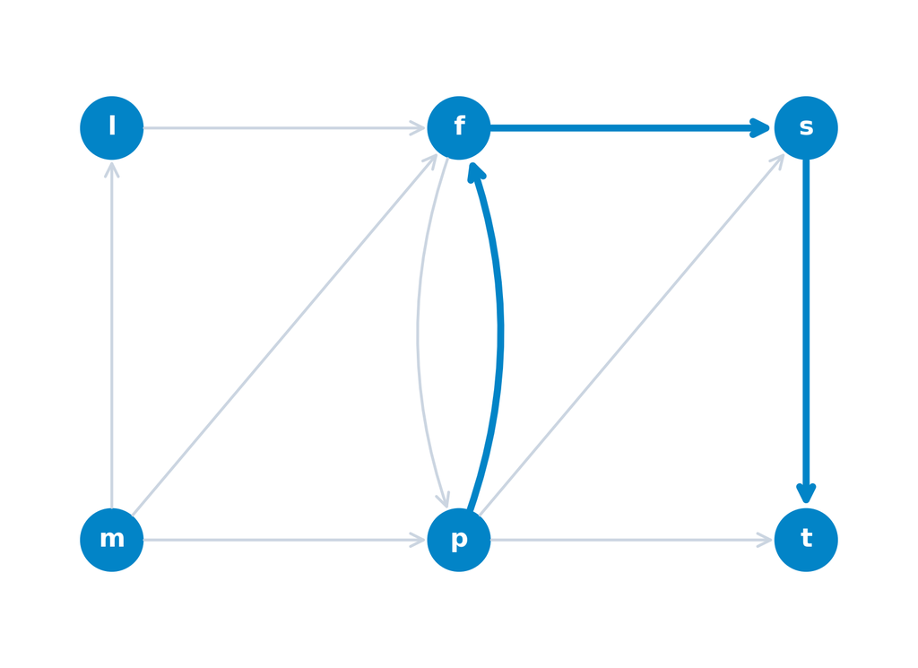

## Ejemplo 3: Cadena simple no elemental ($\mu^3$)

- **Cadena $\mu^3[m, t]$ de longitud $q=5$**:
  $$\begin{aligned}
  \mu^3 = \{ &(m, p), (p, f), (f, s), \\
  &(p, s), (p, t) \}
  \end{aligned}$$
- Visita el nodo París ($p$) dos veces ($m \to p \to f \to s \to p \to t$) $\implies$ **No elemental**.
- No repite ninguno de sus 5 arcos $\implies$ **Simple**.

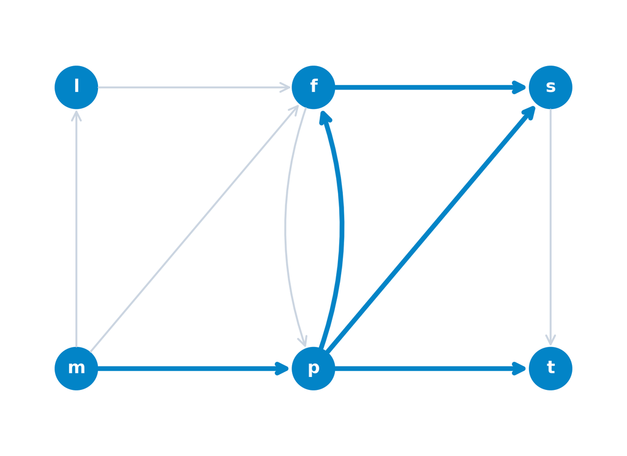

## Ejemplo 4: Cadena ni elemental ni simple ($\mu^4$)

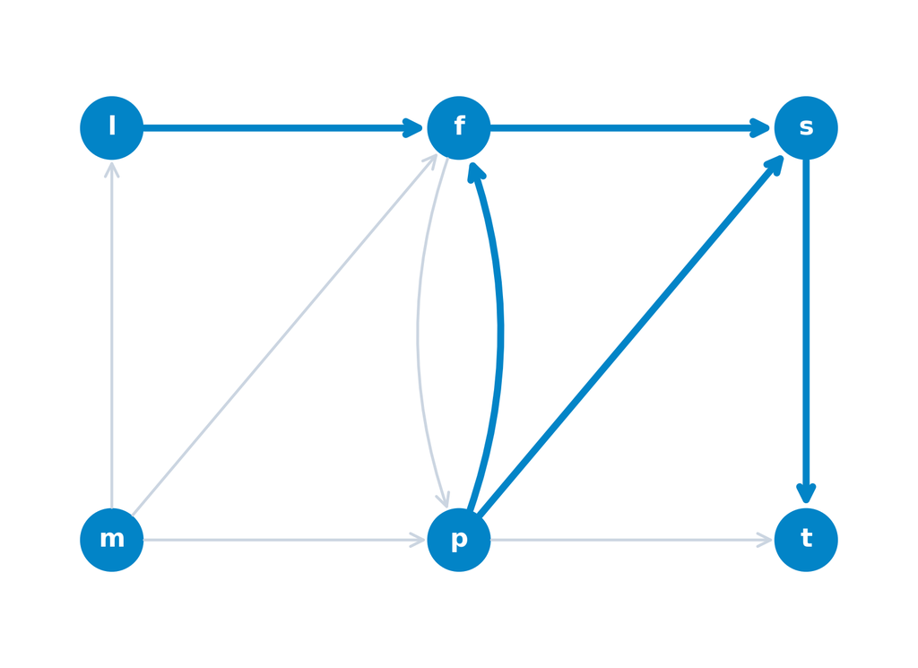

## Ejemplo: Clasificación de cadenas (Análisis analítico)

Evaluación sobre un grafo no dirigido de 5 vértices $V = \{1, 2, 3, 4, 5\}$:

1. **Cadena $\mu_1 = \{\{1,2\}, \{2,3\}, \{3,4\}, \{4,5\}\}$**:
   - Visita 5 vértices distintos sin repetir ninguno $\implies$ **Elemental y simple**.
2. **Cadena $\mu_2 = \{\{1,2\}, \{2,3\}, \{3,4\}, \{4,2\}, \{2,5\}\}$**:
   - Recorre 5 aristas distintas sin repetir ninguna, pero visita el nodo 2 dos veces $\implies$ **Simple pero no elemental**.
3. **Cadena $\mu_3 = \{\{1,2\}, \{2,4\}, \{4,3\}, \{3,2\}, \{2,1\}\}$**:
   - Repite el nodo 2 y duplica la arista $\{1,2\}$ $\implies$ **Ni elemental ni simple**.

## Ejemplo: Clasificación de cadenas (Animación)

[interactive chart not shown]

## Ejemplo: Clasificación de caminos dirigidos (Análisis analítico)

Evaluación sobre una red dirigida de 7 vértices $V = \{a, b, c, d, e, f, g\}$:

1. **Camino $P_1 = ((a,b), (b,c), (c,e), (e,f))$**:
   - Transita en sentido directo por 5 vértices distintos y 4 arcos distintos $\implies$ **Elemental y simple**.
2. **Camino $P_2 = ((c,g), (g,f), (f,b), (b,c), (c,e))$**:
   - No repite arcos, pero el nodo $c$ se visita dos veces ($c \to g \to f \to b \to c \to e$) $\implies$ **Simple pero no elemental**.
3. **Camino $P_3 = ((c,e), (e,f), (f,b), (b,c), (c,e), (e,g))$**:
   - Repite vértices ($c, e$) y duplica el arco $(c,e)$ $\implies$ **Ni elemental ni simple**.

## Ejemplo: Clasificación de caminos dirigidos (Animación)

[interactive chart not shown]

## Métricas de alcance y Diámetro $D(G)$

**Definición: Distancia y Diámetro**

- **Longitud**: Número de arcos $q$ en la cadena.
- **Distancia geodésica $d(i, j)$**: Longitud de la cadena más corta entre $i$ y $j$.
- **Diámetro $D(G)$**: Mayor distancia geodésica entre cualquier par de nodos:
  $$D(G) = \max_{i, j \in V} d(i, j)$$

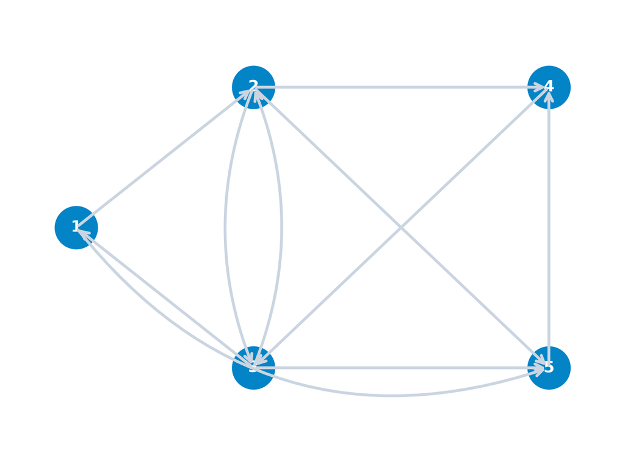

- En esta red de 5 nodos, la máxima distancia geodésica requerida para comunicar cualquier par es de 2 arcos $\implies D(G) = 2$.

## Conectividad y conexidad fuerte

**Definición: Grafo conexo y conexidad fuerte**

Dado un grafo $G = (V, E)$ o digrafo $G = (V, U)$:

- **Grafo conexo (no dirigido)**: Existe al menos una **cadena** entre cualquier par de vértices.
- **Digrafo fuertemente conexo**: Existe al menos un **camino dirigido en ambos sentidos** (de $i$ a $j$ y de $j$ a $i$) entre cualquier par de vértices.
- **Digrafo débilmente conexo**: Su grafo no dirigido subyacente es conexo (existen cadenas), pero carece de caminos dirigidos bidireccionales.

## Ejemplo: Evaluación de conexidad en digrafos

- **Análisis de la red de 7 vértices**:
  - **Conexidad débil**: La red es **débilmente conexa** al existir cadenas no orientadas entre todo par de vértices.
  - **Fallo de conexidad fuerte**: La red **no es fuertemente conexa** porque el nodo $d$ es un **sumidero** al que solo llegan arcos entrantes desde $a, c, g$, sin caminos salientes hacia los demás nodos.

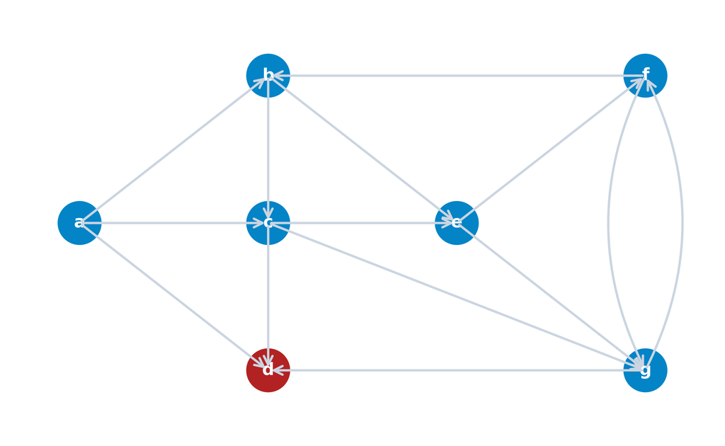

## Componentes conexas como relación de equivalencia

**Definición: Relación R de conexidad**

$i \, R \, j \iff \exists \text{ cadena entre } i \text{ y } j$.

Es una **relación de equivalencia**:

1. **Reflexiva**: $i \, R \, i$ (cadena de longitud 0).
2. **Simétrica**: $i \, R \, j \implies j \, R \, i$.
3. **Transitiva**: $i \, R \, j \land j \, R \, k \implies i \, R \, k$.

Las clases de equivalencia definen las **componentes conexas**.

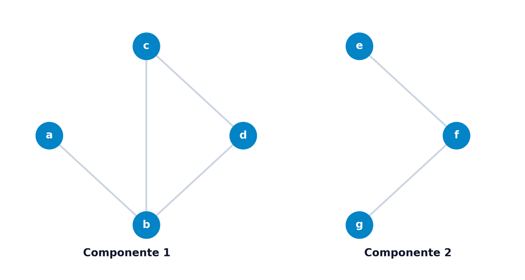

- Grafo descompuesto en 2 componentes conexas disjuntas.

## Ciclos, circuitos y árboles

**Definición: Recorridos cerrados**

- **Ciclo**: Cadena simple cerrada ($v_0 = v_k$).
- **Circuito**: Camino simple cerrado ($v_0 = v_k$).
- **Bucle**: Ciclo de un solo arco/arista $(i, i)$.
- **Árbol**: Grafo conexo acíclico.

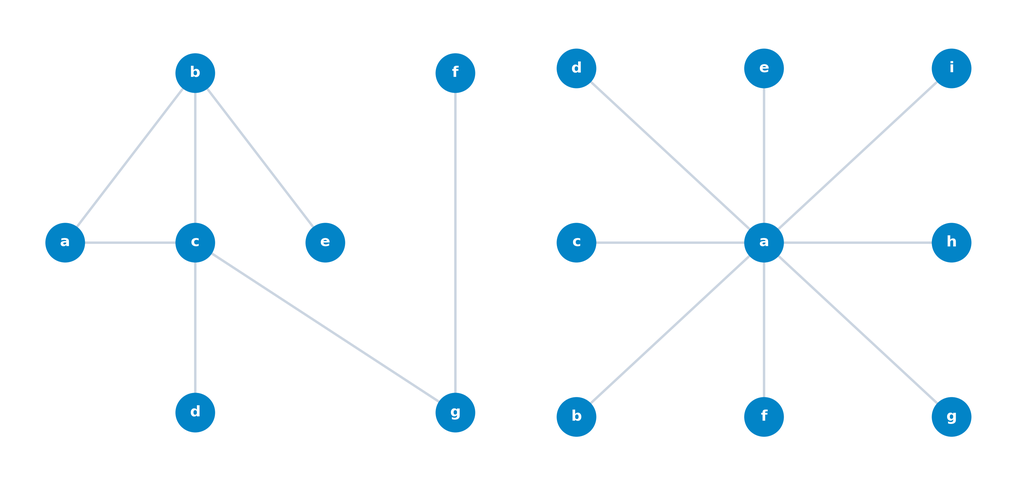

- Izquierda: Grafo con ciclo en triángulo.
- Derecha: Árbol en estrella acíclico.

## Teorema de estructura de ciclos y hojas

**Propiedades estructurales**

Para todo grafo conexo $G = (V, E)$ con $n > 1$:

1. **Ausencia de hojas**: Si todos los vértices tienen grado $d(v) \ge 2$, $G$ contiene **al menos un ciclo**.
2. **Existencia de hojas**: Todo árbol conexo contiene **al menos un vértice pendiente** (hoja con $d(v) = 1$).
3. **Aristas en ciclos**: Una arista $e$ pertenece a un ciclo si y solo si $G \setminus \{e\}$ sigue siendo conexo.

# Grafos planares y bipartitos

## Grafos planares y regiones

**Definición: Grafo planar e incrustación**

- **Grafo Planar**: Admite un dibujo en $\mathbb{R}^2$ sin intersecciones entre aristas.
- **Incrustación planar**: Dibujo sin cruces que divide el plano en $r$ **caras/regiones** (incluyendo 1 región exterior no acotada).

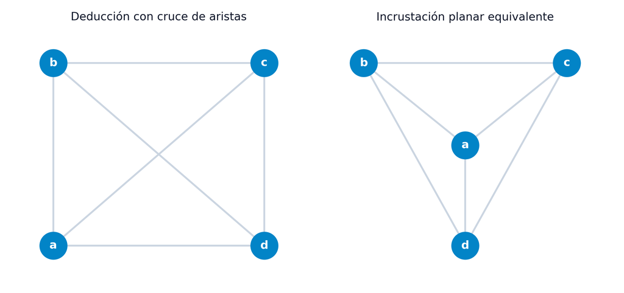

- El clan $K_4$ es **planar** al incrustar el nodo $a$ dentro de la región $\{b,c,d\}$.

## Acertijo de August Möbius (1840): El Rey y sus 5 Hijos

**Testamento del Rey (Acertijo de August Möbius, 1840)**

> *“Un rey ordenó en su testamento que, tras su muerte, su reino fuera dividido entre sus 5 hijos en 5 regiones contiguas de forma que cada región tuviera frontera común con todas las demás 4 regiones. ¿Es posible cumplir la voluntad del rey?”*
- **Pregunta fundamental**: ¿Puede existir un mapa plano dividido en 5 regiones adyacentes donde todas compartan frontera común con las otras cuatro?

## El Acertijo de Möbius y la no planaridad de $K_5$

- **Formulación mediante teoría de redes**:
  - Cumplir el testamento exige que el grafo dual de fronteras sea un **grafo completo de 5 vértices ($K_5$)**.
  - $K_5$ integra $n=5$ vértices y $m = \frac{5 \times 4}{2} = 10$ aristas.
- **Resultado matemático**:
  - La respuesta es **negativa**.
  - $K_5$ es un **grafo no planar**: cualquier intento de incrustar sus 10 aristas en el plano produce al menos un cruce inevitable.

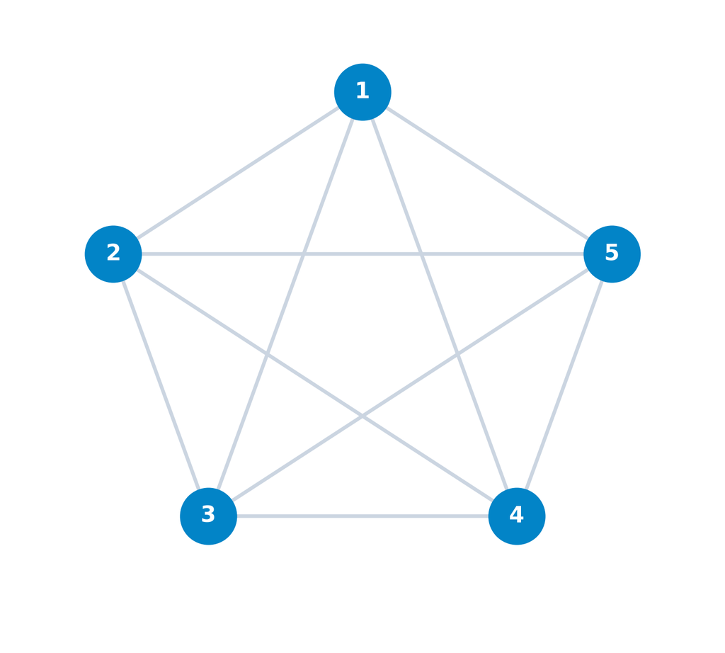

## Grafos bipartitos y Bipartitos completos

**Definición: Grafo bipartito y bipartito completo**

Un grafo $G = (V, E)$ es **bipartito** si su conjunto de vértices admite una partición en dos subconjuntos disjuntos:
$$V = V_1 \cup V_2, \quad V_1 \cap V_2 = \emptyset$$
tal que toda arista conecta un vértice de $V_1$ con un vértice de $V_2$.

- **Bipartito Completo $K_{n_1, n_2}$**: Contiene todas las $n_1 \cdot n_2$ aristas entre $V_1$ y $V_2$.

**Caracterización**

Un grafo es bipartito $\iff$ **no contiene ningún ciclo de longitud impar**.

## Problema de los tres servicios de Dudeney (1917)

**Acertijo de Henry Ernest Dudeney (1917)**

> *“¿Es posible canalizar las conducciones subterráneas de tres suministros esenciales (agua, gas y electricidad) hacia tres viviendas independientes de modo que ninguna tubería o cable se cruce con otro en el plano?”*
- **Pregunta fundamental**: ¿Es posible conectar 3 fuentes de suministro ($A, G, E$) a 3 casas ($C_1, C_2, C_3$) sin que los tendidos de tuberías o cables se intercepten en el plano?

## El Problema de Dudeney y la no planaridad de $K_{3,3}$

- **Formulación mediante teoría de redes**:
  - Modela la incrustación del **grafo bipartito completo $K_{3,3}$** ($n_1=3$ suministros, $n_2=3$ casas, $m = 3 \times 3 = 9$ aristas).
- **Resultado matemático**:
  - La respuesta al acertijo es **negativa**.
  - $K_{3,3}$ es un **grafo no planar**: tras trazar 8 conducciones, la novena queda atrapada en una cara acotada sin poder completarse sin cruzar una tubería previa.

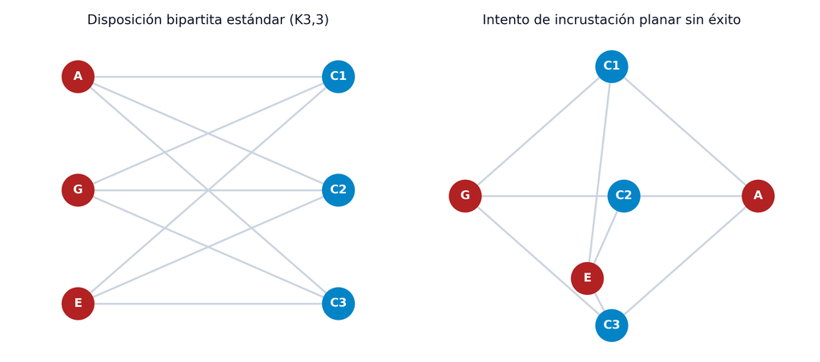

## Homeomorfismo y Teorema de Kuratowski (1930)

**Definición: Homeomorfismo**

Dos grafos son **homeomórficos** si se obtienen uno del otro mediante subdivisión elemental de aristas (insertar/suprimir nodos de grado 2).

**Teorema de Kuratowski (1930)**

Un grafo $G$ es **planar** $\iff$ **no contiene ningún subgrafo homeomórfico a $K_5$ ni a $K_{3,3}$**.

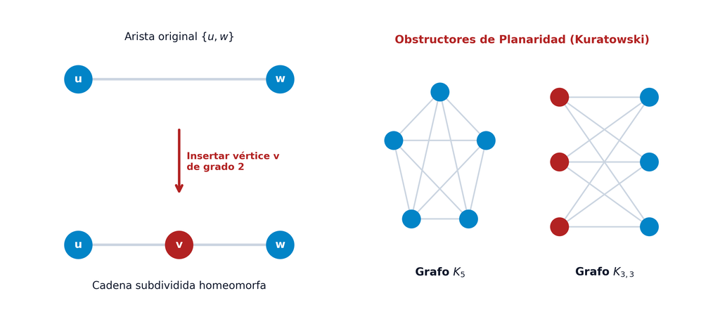

## Demostración: Grafo de Petersen

- **Grafo de Petersen**: Grafo 3-regular con 10 vértices y 15 aristas.
- **No planaridad**: Contiene un subgrafo parcial homeomórfico a $K_{3,3}$.
- **Subdivisión**: Nodos rojos $V_1 = \{j, a, d\}$, nodos azules $V_2 = \{e, f, b\}$. Vértices $g, h, i, c$ actúan de grado 2.

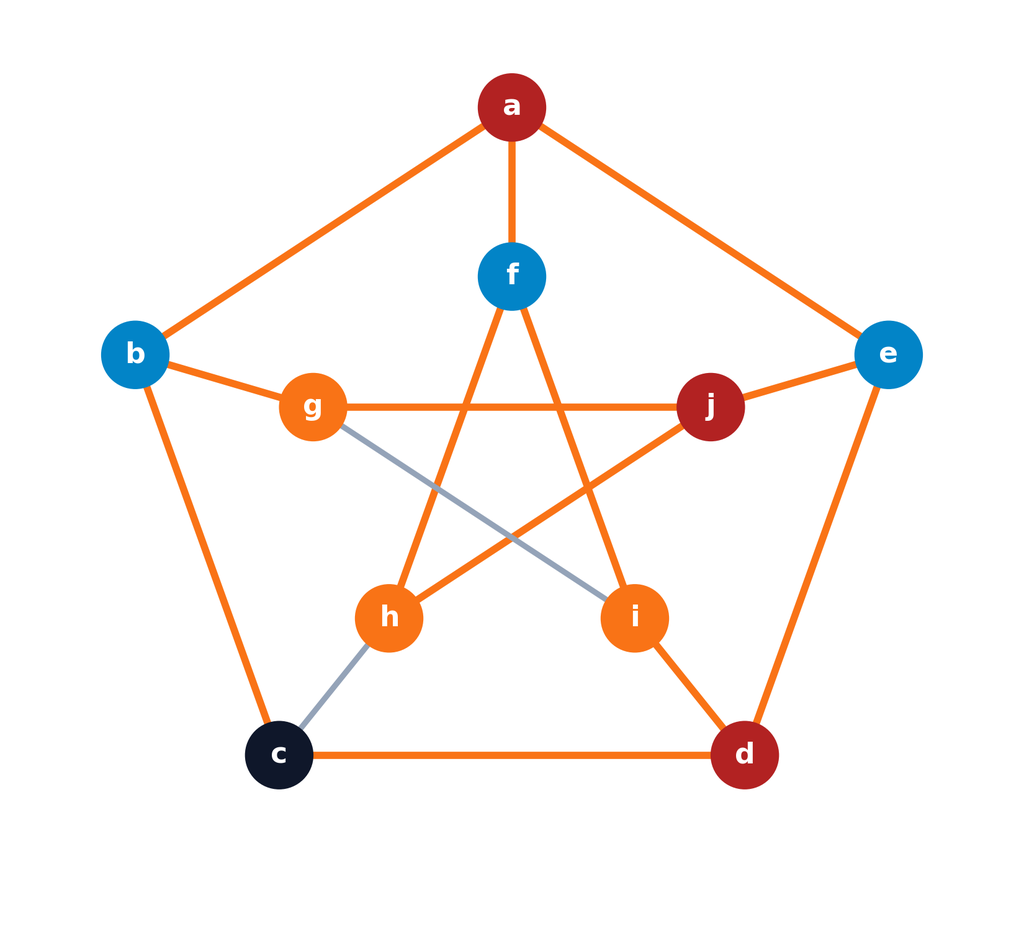

## Fórmula planar de Euler

**Fórmula planar de Euler**

En todo grafo planar conexo con $n$ vértices, $m$ aristas y $r$ regiones (incluyendo la cara exterior no acotada):
$$n + r = m + 2$$

- **Significado geométrico**:
  - Relación invariante entre vértices, aristas y caras sobre la superficie del plano.
  - Permite deducir las cotas superiores absolutas sobre la densidad de aristas en grafos planares.

## Corolarios de la Fórmula de Euler

**Corolario: Desigualdades de planaridad**

1. En todo grafo planar conexo simple con $n \ge 3$:
   $$m \le 3n - 6$$
2. En todo grafo planar conexo simple **bipartito** (sin triángulos):
   $$m \le 2n - 4$$

## Ejemplo: Prueba analítica de no planaridad

- **Prueba para $K_5$ ($n=5, m=10$)**:
  - Condición de planaridad para $n \ge 3$:
    $$m \le 3n - 6$$
  - Evaluación:
    $$10 \le 3(5) - 6 = 9 \quad \text{(FALSO)}$$
  - **Conclusión**: $K_5$ es **no planar**.
- **Prueba para $K_{3,3}$ ($n=6, m=9$)**:
  - Grafo bipartito sin triángulos:
    $$m \le 2n - 4$$
  - Evaluación:
    $$9 \le 2(6) - 4 = 8 \quad \text{(FALSO)}$$
  - **Conclusión**: $K_{3,3}$ es **no planar**.

# Representación de grafos

## Matriz de incidencia (Grafo no dirigido)

**Definición: Matriz de incidencia nodo-arista**

Dada una red no dirigida $G = (V, E)$, la **matriz de incidencia** $A \in \mathbb{R}^{n \times m}$ se define como:
$$\small
a_{ik} = \begin{cases}
1 & \text{si } i \text{ es extremo de arista } e_k \\
0 & \text{en otro caso}
\end{cases}$$

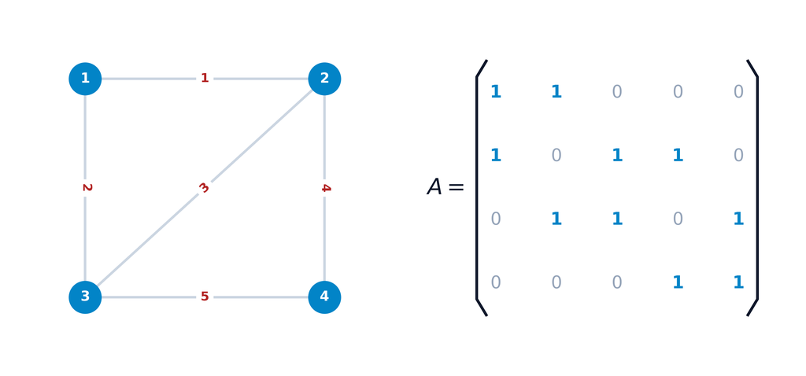

- **Suma por columnas**: Toda columna de $A$ suma exactamente $2$ (cada arista posee $2$ extremos).

## Matriz de incidencia (Digrafo y TUM)

**Definición: Matriz de incidencia nodo-arco**

Dado un digrafo $G = (V, U)$, la matriz $A \in \mathbb{R}^{n \times m}$ registra la orientación:
$$\small
a_{ik} = \begin{cases}
+1 & \text{si } i \text{ es el origen del arco } u_k \\
-1 & \text{si } i \text{ es el destino del arco } u_k \\
0 & \text{en otro caso}
\end{cases}$$

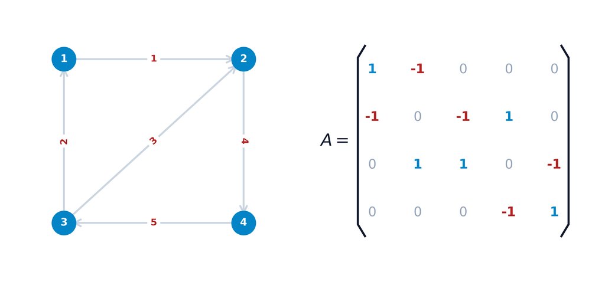

- **Propiedad de Total Unimodularidad (TUM)**: Todo subdeterminante es $0, \pm 1$, garantizando soluciones enteras en flujos.

## Matriz de adyacencia (Grafo no dirigido)

**Definición: Matriz de adyacencia no dirigida**

Dado un grafo simple no dirigido $G = (V, E)$, la **matriz de adyacencia** $B \in \mathbb{R}^{n \times n}$ se define como:
$$\small
b_{ij} = \begin{cases}
1 & \text{si } \{i, j\} \in E \\
0 & \text{en otro caso}
\end{cases}$$

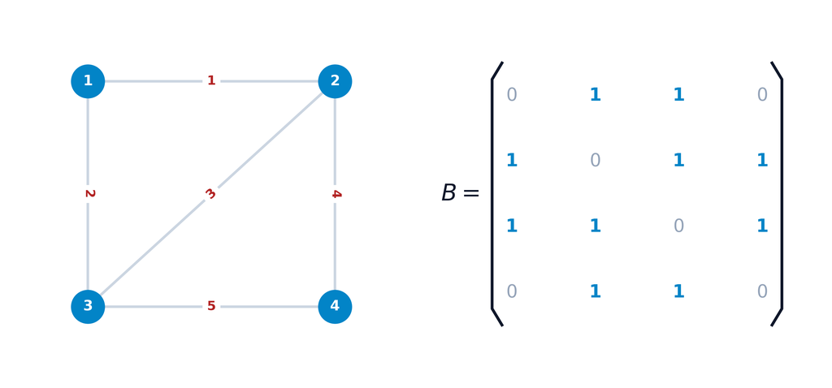

- **Matriz simétrica**: $B = B^T$ con ceros en la diagonal ($b_{ii} = 0$).